# Naive Bayes

Vamos a hacer un pequeño modelo estilo naive bayes, más que todo para practicar.

## Bibliotecas a usar

```r
library(MASS)
library(e1071)
library(ggcorrplot)
library(pROC)
library(caret)
library(tidyverse)


source("../R/Utils.R")
```

## Cargar los datos

```r
df <-  read.csv("../data/datos_eda.csv", sep = ';')
head(df)
```

|  | id | d1 | d2 | d3 | d4 | d5 | edad | es_cuidador | dbs | anio_diagnostico | educ | empleo | genero | tipo_medico | estado_marital | anio_comienzo_med | anio_comienzo_sintomas | paquetes_por_dia | facilidad_celular | fumo | cirugia | videollamada | anios_fumo | diagnostico_pro |
| --- | --- | --- | --- | --- | --- | --- | --- | --- | --- | --- | --- | --- | --- | --- | --- | --- | --- | --- | --- | --- | --- | --- | --- | --- |
| 1 | 24665 | 35.23343 | -178.8503 | 0.374910 | 0.096570 | 0.032114 | 71 | true | false | 2011 | High School Diploma/GED | Retired | Female | Parkinson Disease/Movement Disorder Specialist | Married or domestic partnership | 2011 | 2011 | NA | Neither easy nor difficult | false | false | false | NA | true |
| 2 | 21472 | 35.06466 | -177.2032 | 0.379995 | 0.115948 | 0.024917 | 48 | false | NA | NA | Some college | Employment for wages | Male | NA | Married or domestic partnership | NA | NA | NA | Very easy | false | NA | true | NA | false |
| 3 | 25155 | 53.76691 | -178.8864 | 0.359551 | 0.109389 | 0.058175 | 73 | false | false | 2005 | Some college | Retired | Male | NA | Married or domestic partnership | 2005 | 2005 | 1 | Neither easy nor difficult | true | false | false | 4 | true |
| 4 | 22829 | 31.19639 | -197.1547 | 0.325620 | 0.103234 | 0.069262 | 50 | false | false | 2014 | High School Diploma/GED | Self-employed | Male | General Neurologist (non-Parkinson Disease specialist) | Married or domestic partnership | NA | 2012 | NA | Very easy | false | false | true | NA | true |
| 5 | 24848 | 36.34814 | -117.8097 | 0.271464 | 0.102776 | 0.005820 | 57 | false | false | 2012 | 4-year college degree | Self-employed | Female | Parkinson Disease/Movement Disorder Specialist | Married or domestic partnership | 2012 | 2011 | 1 | Very easy | true | false | true | 15 | true |
| 6 | 21417 | 34.78511 | -191.4573 | 0.395302 | 0.120893 | 0.016126 | 51 | false | false | 2010 | Masters Degree | Employment for wages | Male | Parkinson Disease/Movement Disorder Specialist | Married or domestic partnership | 2010 | 2009 | NA | Very easy | false | false | true | NA | true |

```r
names(df)
```

```
 [1] "id"                     "d1"                     "d2"                     "d3"
 [5] "d4"                     "d5"                     "edad"                   "es_cuidador"
 [9] "dbs"                    "anio_diagnostico"       "educ"                   "empleo"
[13] "genero"                 "tipo_medico"            "estado_marital"         "anio_comienzo_med"
[17] "anio_comienzo_sintomas" "paquetes_por_dia"       "facilidad_celular"      "fumo"
[21] "cirugia"                "videollamada"           "anios_fumo"             "diagnostico_pro"
```

Observamos que id es una variable que no queremos usar.

```r
df <- df %>% select(-id) %>% mutate(diagnostico_pro = factor(diagnostico_pro))
```

## Modelo

El modelo que vamos a buscar plantear uno que este diagnostico_pro como variable respuesta en función de las otras. Como tenemos la restricción de independencia de las variables predictoras vamos a realizar un heatmap entre las variables numéricas.

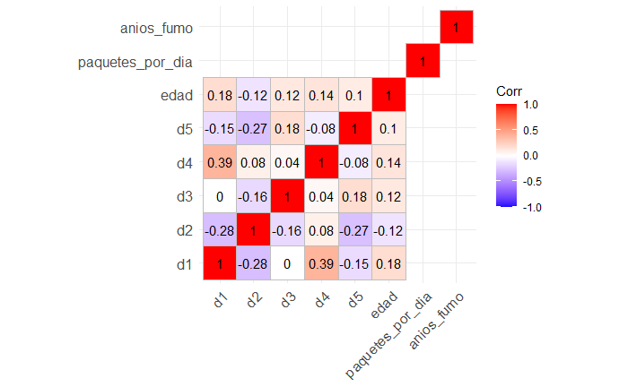

```r
var_numericas <- c("d1",  "d2", "d3", "d4", "d5", "edad", "paquetes_por_dia", "anios_fumo" )

df %>%
  select(all_of(var_numericas)) %>%
  cor(method = "pearson") %>%
  ggcorrplot(lab = TRUE)
```

vemos que hay problemas con las variables paquetes_por_dia y anios_fumo. Sera por la cantidad de NAs?

```r
df %>%
  select(all_of(var_numericas)) %>%
  map_int(~ sum(is.na(.)))
```

```
              d1               d2               d3               d4               d5             edad
               0                0                0                0                0                0
paquetes_por_dia       anios_fumo
            1569             1471
```

Con esto llegamos a la conclusión que es problema son los NAs, entonces los exlcuimos.

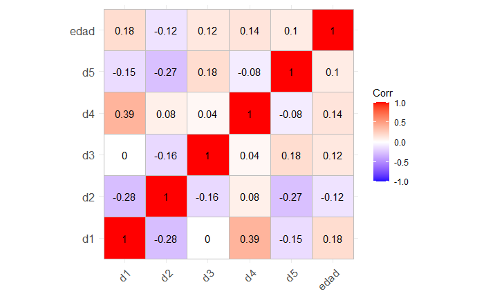

```r
var_numericas <- var_numericas[-c(7, 8)]

df %>%
  select(all_of(var_numericas)) %>%
  cor(method = "pearson") %>%
  ggcorrplot(lab = TRUE)
```

No observamos que exista variables altamente correlacionada.

Además, deberemos verificar que su distrbución sea, o almenos aproximadamente, normal.

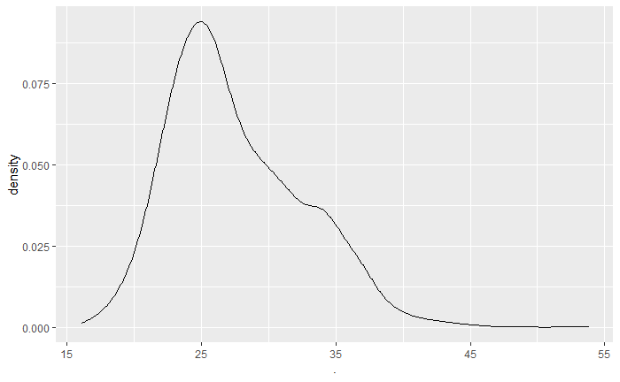

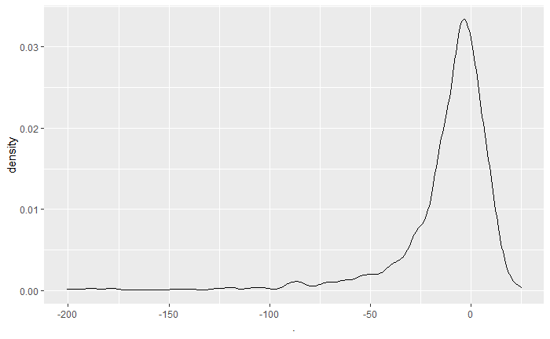

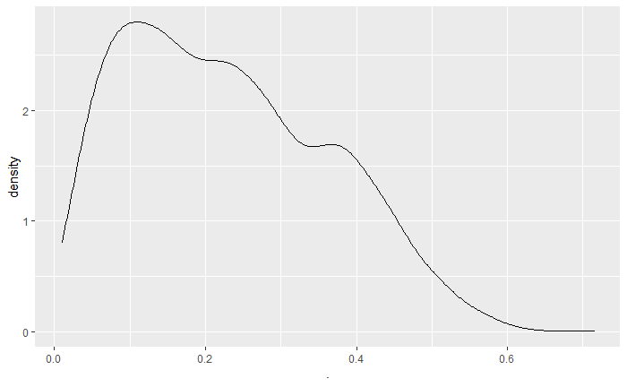

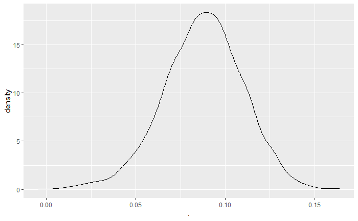

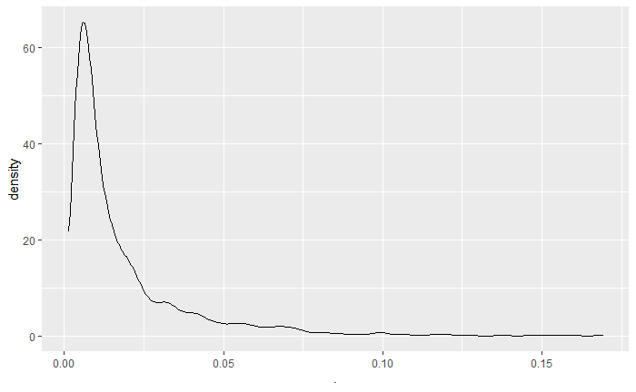

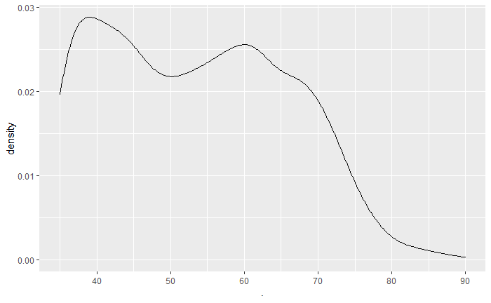

```r
df %>%
  select(all_of(var_numericas)) %>%
  map(~ ggplot(df, aes(.)) + geom_density())
```

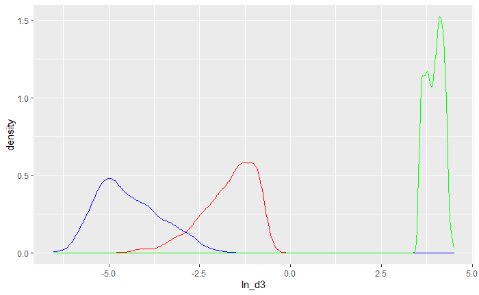

```r
df %>%
  select(d3, d5, edad) %>%
  mutate(ln_d3 = log(d3, exp(1)),
         ln_d5 = log(d5, exp(1)),
         ln_edad = log(edad, exp(1))) %>%
  ggplot() +
  geom_density(aes(ln_d3), color = "red") +
  geom_density(aes(ln_d5), color = "blue") +
  geom_density(aes(ln_edad), color = "green")
```

Observamos que las varibles adpotan una forma más semejante a una normal con esta transformación.

```r
df2 <- df %>%
  mutate(ln_d3 = log(d3, exp(1)),
         ln_d5 = log(d5, exp(1)),
         ln_edad = log(edad, exp(1)))

var_numericas <- c("d1",  "d2", "ln_d3", "d4", "ln_d5", "ln_edad")
```

Para las variables categóricas vamos a utilizar

```r
var_categ <- c("educ", "empleo",  "genero",  "estado_marital",  "facilidad_celular", "fumo")
```

**¿Cómo se podría ver si son independientes las va categóricas?**

```r
# Nos quedamos con las vaiables que queremos

variables <- c(var_numericas, var_categ, "diagnostico_pro")

df_bayes <- df2 %>%
  select(all_of(variables))

# Dividimos el dataste

set.seed(100)
indices_train <- createDataPartition(df_bayes$diagnostico_pro, p = .7, list = FALSE)
datos_train <- df_bayes[indices_train, ]
datos_test <- df_bayes[-indices_train, ]

# Creamos el modelo

modelo_bayes <- naiveBayes(diagnostico_pro ~ ., data = datos_train)
modelo_bayes
```

```
Naive Bayes Classifier for Discrete Predictors

Call:
naiveBayes.default(x = X, y = Y, laplace = laplace)

A-priori probabilities:
Y
    false      true
0.5763039 0.4236961

Conditional probabilities:
       d1
Y           [,1]     [,2]
  false 26.34297 4.487826
  true  29.05675 5.049883

       d2
Y             [,1]     [,2]
  false  -9.755118 23.73559
  true  -16.716245 30.14757

       ln_d3
Y            [,1]      [,2]
  false -1.736257 0.7460703
  true  -1.643826 0.7560842

       d4
Y             [,1]       [,2]
  false 0.08512808 0.02179866
  true  0.09090098 0.02264045

       ln_d5
Y            [,1]      [,2]
  false -4.449817 0.8514257
  true  -4.462090 0.8993963

       ln_edad
Y           [,1]      [,2]
  false 3.845634 0.2152530
  true  4.105233 0.1681236
```

[output cut: 27 more lines]

```
  true  0.092705167                     0.808510638 0.009118541 0.009118541          0.042553191
       estado_marital
Y           Widowed
  false 0.013422819
  true  0.037993921

       facilidad_celular
Y         Difficult        Easy Neither easy nor difficult Very Difficult   Very easy
  false 0.003351955 0.094972067                0.008938547    0.000000000 0.892737430
  true  0.025835866 0.348024316                0.177811550    0.004559271 0.443768997

       fumo
Y           false      true
  false 0.6269006 0.3730994
  true  0.6514460 0.3485540
```

Ahora que tenemos el modelo, comenzamos realizando las predicciones

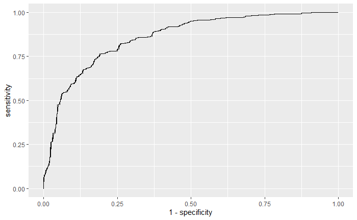

```r
predicciones_bayes <- predict(modelo_bayes, datos_test, type = "raw")
objeto_roc_bayes <- roc(datos_test$diagnostico_pro, predicciones_bayes[,"true"])
data.frame(sensitivity = objeto_roc_bayes$sensitivities,
           specificity = objeto_roc_bayes$specificities) %>%
  ggplot(aes(1 - specificity, sensitivity)) +
  geom_line()
```

```r
auc(objeto_roc_bayes)
```

```
Area under the curve: 0.8577
```

Observamos que este modelo consigue un buen valor de AUC. Para seguir, vamos a armar rapidamente una regresión logística usando las mismas variables, para luego comparar ambos modelos.

Como la regresión logística no pone ninguna restrcción sobre las variables independientes, vamos a usar más variables, primero veamos cuales tienen mayor cantidad de NAs

```r
# Obsearvamos la cantidad de NAs
df %>%
  map_int(~ sum(is.na(.)))
```

```
                    d1                     d2                     d3                     d4
                     0                      0                      0                      0
                    d5                   edad            es_cuidador                    dbs
                     0                      0                      3                    268
      anio_diagnostico                   educ                 empleo                 genero
                  1287                      7                      8                      2
           tipo_medico         estado_marital      anio_comienzo_med anio_comienzo_sintomas
                  1073                      4                   1357                   1120
      paquetes_por_dia      facilidad_celular                   fumo                cirugia
                  1569                      1                     65                    383
          videollamada             anios_fumo        diagnostico_pro
                     4                   1471                      0
```

```r
# Elegimos las variables a usar
vars_cuanti <- c("d1", "d2", "d3", "d4", "d5", "edad")
vars_cuali <- c("educ", "empleo", "genero", "estado_marital", "facilidad_celular")
vars <- c(vars_cuanti, vars_cuali, "diagnostico_pro")

df_logistica <- df %>%
  select(all_of(vars)) %>%
  drop_na()

# ¿Cúantas observaciones nos quedan?
nrow(df_logistica)
```

```
[1] 2200
```

```r
# Separamos los datos
set.seed(999)
indices_train <- createDataPartition(df_logistica$diagnostico_pro, p = .7, list = FALSE)
datos_train <- df_logistica[indices_train,]
datos_test <- df_logistica[-indices_train,]
```

Con esto armado, vamos a entrenar el modelo

```r
modelo <- train(diagnostico_pro ~ .,
                data = df_logistica,
                method = "glm",
                family = "binomial")
```

[output not shown]

Buscando en internet encontre que este problema puede deberse a que son desbalanceados los niveles de las distintas variables categóricas, vamos a armar unas tablas de frecuencias para ver si esto es verdad

```r
armar_tabla_frecuencia(df_logistica, vars_cuali)
```

```
$educ

  2-year college degree   4-year college degree         Doctoral Degree High School Diploma/GED
                    137                     573                     292                     115
         Masters Degree            Some college    Some graduate school        Some high school
                    553                     344                     171                      15

$empleo

         A homemaker            A student Employment for wages          Out of work              Retired
                  34                   10                 1115                   57                  537
       Self-employed       Unable to work
                 328                  119

$genero

              Female                 Male Prefer not to answer
                 572                 1627                    1

$estado_marital

                       Divorced Married or domestic partnership                           Other
                            182                            1721                              11
                      Separated            Single never married                         Widowed
                             27                             209                              50

$facilidad_celular

                 Difficult                       Easy Neither easy nor difficult
                        34                        430                        175
            Very Difficult                  Very easy
                         8                       1553
```

Observamos que evidentemente hay casos con estos problemas, vamso a solucionar creando nuevos niveles

```r
# Dividir educ en Posgraduate - College - Highschool
df_logistica <- df_logistica %>%
  mutate(educ = fct_collapse(educ,
                           "Postgraduate" = c("Doctoral Degree", "Masters Degree"),
                           "College" = c("2-year college degree", "4-year college degree", "Some graduate school"),
                           "HighSchool" = c("High School Diploma/GED", "Some college", "Some high school")))

# Emplemos lo agrupamos en Working - Not Working
df_logistica <- df_logistica %>%
  mutate(empleo = fct_collapse(empleo,
                               "Working" = c("A homemaker", "Employment for wages", "Self-employed"),
                               "Not Working" = c("A student", "Out of work", "Retired", "Unable to work" )))

# Genero sacamos la observacion con Prefer not to answer
df_logistica <- df_logistica %>%
  filter(genero != "Prefer not to answer")

# Estado marital lo convertimos en Married - Not Married
df_logistica <- df_logistica %>%
  mutate(estado_marital = fct_collapse(estado_marital,
                                       "Married" = c("Married or domestic partnership"),
                                       "Not Married" = c("Divorced", "Other", "Separated", "Single never married", "Widowed")))

# Para facilidad celular lo convertimos en Easy - Not Easy
df_logistica <- df_logistica %>%
  mutate(facilidad_celular = fct_collapse(facilidad_celular,
                                    "Not Easy" = c("Difficult", "Neither easy nor difficult", "Very Difficult"),
                                    "Easy" = c("Easy", "Very easy")))

# Probamos nuevamente para ver si ha pocas observaciones en algún nivel
armar_tabla_frecuencia(df_logistica, vars_cuali)
```

```
$educ

     College Postgraduate   HighSchool
         881          844          474

$empleo

    Working Not Working
       1476         723

$genero

Female   Male
   572   1627

$estado_marital

Not Married     Married
        479        1720

$facilidad_celular

Not Easy     Easy
     217     1982
```

Si bien observamos que existen varios niveles desbalanceados, todos poseen una cantidad de observaciones acpetables. Volvemos a intetar entrenar el modelo

```r
# Separamos los datos
set.seed(999)
indices_train <- createDataPartition(df_logistica$diagnostico_pro, p = .7, list = FALSE)
datos_train <- df_logistica[indices_train,]
datos_test <- df_logistica[-indices_train,]

modelo_logistica <- train(diagnostico_pro ~ .,
                          data = datos_train,
                          method = "glm",
                          family = "binomial")

summary(modelo_logistica)
```

```
Call:
NULL

Deviance Residuals:
    Min       1Q   Median       3Q      Max
-3.2058  -0.6813  -0.3731   0.7245   2.3240

Coefficients:
                       Estimate Std. Error z value Pr(>|z|)
(Intercept)           -6.019337   0.843124  -7.139 9.38e-13 ***
d1                     0.075906   0.020122   3.772 0.000162 ***
d2                    -0.002575   0.002822  -0.912 0.361590
d3                     0.829369   0.510054   1.626 0.103940
d4                     1.913078   3.298862   0.580 0.561968
d5                    -0.697003   3.469724  -0.201 0.840791
edad                   0.091908   0.007088  12.966  < 2e-16 ***
educPostgraduate      -0.167259   0.147632  -1.133 0.257235
educHighSchool        -0.277676   0.186738  -1.487 0.137019
`empleoNot Working`    0.611469   0.157330   3.887 0.000102 ***
generoMale            -0.127266   0.204117  -0.623 0.532960
estado_maritalMarried  0.404964   0.170412   2.376 0.017483 *
facilidad_celularEasy -2.291123   0.322523  -7.104 1.21e-12 ***
---
Signif. codes:  0 ‘***’ 0.001 ‘**’ 0.01 ‘*’ 0.05 ‘.’ 0.1 ‘ ’ 1

(Dispersion parameter for binomial family taken to be 1)

    Null deviance: 2099.2  on 1539  degrees of freedom
Residual deviance: 1420.9  on 1527  degrees of freedom
AIC: 1446.9

Number of Fisher Scoring iterations: 5
```

Este es el primer modelo, donde incluimos todas las variables. En los resultados vemos que existen variables que no resultan significativas para el modelo. Aplicamos un metodo stepwise para seleccionar aquellas que son más importantes.

```r
# Para esto necesitamos la bilbioteca MASS
modelo_logistica <- train(diagnostico_pro ~ .,
                          data = datos_train,
                          method = "glmStepAIC",
                          family = "binomial",
                          trace = FALSE)
```

Ahora que tenemos el modelo podemos hacer predicciones y compararlo con el modelo naive bayes para observar cual tiene una mejor perfomance.

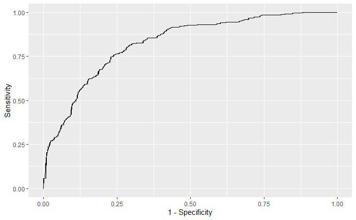

```r
predicciones_logistica <- predict(modelo_logistica, datos_test, type = "prob")
objeto_roc_logistica <- roc(datos_test$diagnostico_pro, predicciones_logistica[,"true"])
data.frame(Sensitivity = objeto_roc_logistica$sensitivities,
           Specificity = objeto_roc_logistica$specificities) %>%
  ggplot(aes(1 - Specificity, Sensitivity)) +
  geom_line()
```

```r
auc(objeto_roc_logistica)
```

```
Area under the curve: 0.8272
```

```r
auc(objeto_roc_bayes)
```

```
Area under the curve: 0.8577
```

Vemos que el modelo de bayes perfoma mejor que el modelo de regresión logística, con un AUC de 0.85 contra uno de 0.82.